# R Lab 4 Key

## Setting Up: Billboard music data

### Libraries

```r
library(tidyverse)
library(psych)
library(scales)
library(forcats)
library(viridis)
```

### Data

For this section you will be using Billboard music data from TidyTuesday. See https://github.com/rfordatascience/tidytuesday/tree/master/data/2021/2021-09-14 for more detailed information about the dataset.

```r
set.seed(8765)
billboard <- readr::read_csv('https://raw.githubusercontent.com/rfordatascience/tidytuesday/master/data/2021/2021-09-14/audio_features.csv') %>% sample_n(5000)
```

Let’s glimpse at the data.

```r
glimpse(billboard)
```

```
## Rows: 5,000
## Columns: 22
## $ song_id                   <chr> "Magic ManHeart", "Light Up The WorldGlee Ca…
## $ performer                 <chr> "Heart", "Glee Cast", "Phil Vassar", "Cathy …
## $ song                      <chr> "Magic Man", "Light Up The World", "Last Day…
## $ spotify_genre             <chr> "['folk-pop', 'indie folk', 'indie pop', 'ne…
## $ spotify_track_id          <chr> "4sUlsy0tPv9n5nqrqeA0lE", "1Et2wMhDPqbu5y4sG…
## $ spotify_track_preview_url <chr> NA, "https://p.scdn.co/mp3-preview/b009108a2…
## $ spotify_track_duration_ms <dbl> 328360, 223653, 234306, NA, 46253, NA, 16062…
## $ spotify_track_explicit    <lgl> FALSE, FALSE, FALSE, NA, FALSE, NA, FALSE, F…
## $ spotify_track_album       <chr> "Dreamboat Annie", "Glee: The Musi", "Totall…
## $ danceability              <dbl> 0.435, 0.689, 0.557, NA, 0.632, NA, 0.615, 0…
## $ energy                    <dbl> 0.444, 0.796, 0.549, NA, 0.323, NA, 0.479, 0…
## $ key                       <dbl> 7, 10, 0, NA, 10, NA, 7, 2, 8, 9, 5, 2, 5, 9…
## $ loudness                  <dbl> -12.816, -5.472, -6.674, NA, -14.042, NA, -8…
## $ mode                      <dbl> 0, 1, 1, NA, 0, NA, 1, 1, 0, 0, 1, 0, 1, 0, …
## $ speechiness               <dbl> 0.0336, 0.0406, 0.0246, NA, 0.9510, NA, 0.06…
## $ acousticness              <dbl> 0.159000, 0.000599, 0.272000, NA, 0.811000, …
## $ instrumentalness          <dbl> 7.05e-04, 0.00e+00, 0.00e+00, NA, 0.00e+00, …
## $ liveness                  <dbl> 0.4570, 0.1200, 0.1090, NA, 0.1020, NA, 0.27…
## $ valence                   <dbl> 0.734, 0.857, 0.268, NA, 0.769, NA, 0.788, 0…
## $ tempo                     <dbl> 103.818, 118.029, 139.945, NA, 171.053, NA, …
## $ time_signature            <dbl> 4, 4, 3, NA, 4, NA, 4, 3, 4, 4, 4, 4, 4, 4, …
## $ spotify_track_popularity  <dbl> 59, 48, 30, NA, 18, NA, 45, 14, 63, 63, 51, …
```

## Correlation 1

### Exercise 1 -

Use the `cor.test()` function to run a correlation. Select any two numeric variables of interest for your correlation. Interpret the output in terms of significance and direction.

```r
cor.test(billboard$spotify_track_duration_ms,
         billboard$spotify_track_popularity)
```

```
##
##  Pearson's product-moment correlation
##
## data:  billboard$spotify_track_duration_ms and billboard$spotify_track_popularity
## t = 10.871, df = 4147, p-value < 2.2e-16
## alternative hypothesis: true correlation is not equal to 0
## 95 percent confidence interval:
##  0.1367243 0.1958990
## sample estimates:
##       cor
## 0.1664615
```

There is a small, significant (p < 0.05) positive correlation between track popularity and track duration.

### Exercise 2 -

Create a ggplot scatterplot visualization of the two variables you selected for the correlation. Add a geom_smooth regression “lm” line to the plot. Interpret what you see. Make sure you clean up the labels and add a theme.

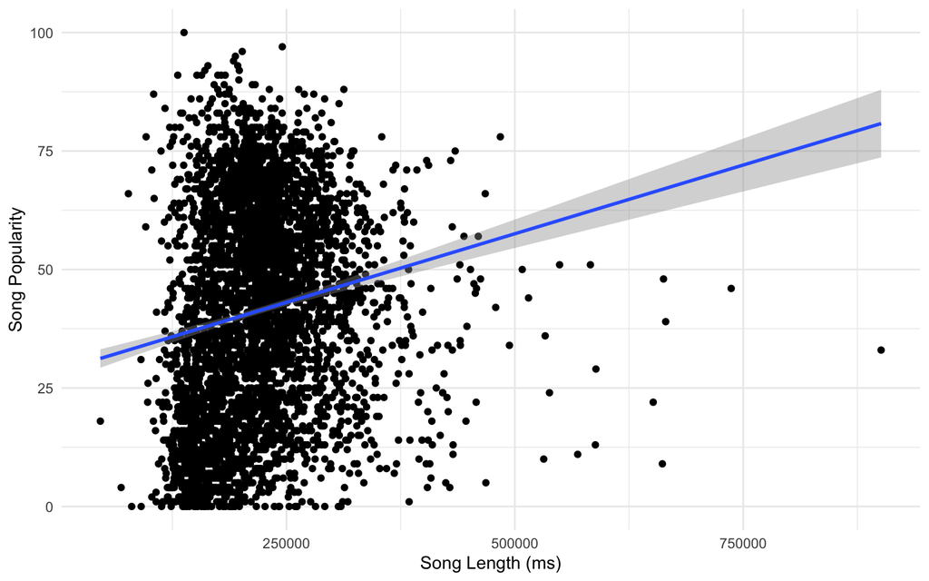

```r
ggplot(billboard, aes(spotify_track_duration_ms,
                  spotify_track_popularity)) +
  geom_point() +
  theme_minimal() +
  geom_smooth(method = "lm") +
  labs(x = "Song Length (ms)", y = "Song Popularity")
```

While it is positive, we see most of the song length clustering is around 250000 ms.

## Correlation 2

### Exercise 3 -

Use the `cor.test()` function to run a different correlation. Select any two numeric variables of interest (different from exercise 1) for your correlation. Interpret the output in terms of significance and direction.

```r
cor.test(billboard$energy, billboard$loudness)
```

```
##
##  Pearson's product-moment correlation
##
## data:  billboard$energy and billboard$loudness
## t = 61.435, df = 4133, p-value < 2.2e-16
## alternative hypothesis: true correlation is not equal to 0
## 95 percent confidence interval:
##  0.6746030 0.7064815
## sample estimates:
##       cor
## 0.6908779
```

There is a strong positive and significant (p < 0.05) correlation between the energy and loudness of a song.

### Exercise 4 -

Create a ggplot scatterplot visualization of the two variables you selected for the previous correlation. Add a geom_smooth regression “lm” line to the plot. Interpret what you see. Make sure you clean up the labels and add a theme.

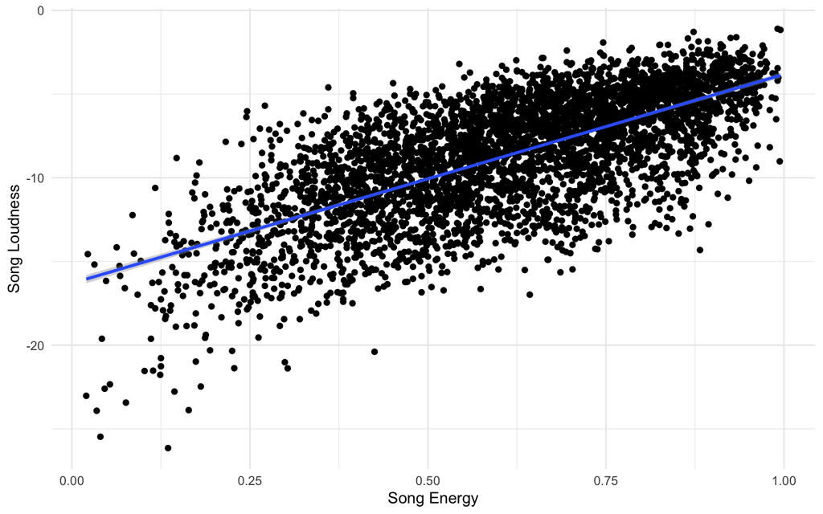

```r
ggplot(billboard, aes(energy, loudness)) +
  geom_point() +
  theme_minimal() +
  geom_smooth(method = "lm") +
  labs(x = "Song Energy", y = "Song Loudness")
```

Similar to the correlation output, we see a strong positive linear relationship between the two variables.

## Correlation 3

### Exercise 5 -

Use the `cor.test()` function to run a different correlation. Select any two numeric variables of interest (different from exercise 1 & 3) for your correlation. Interpret the output in terms of significance and direction.

```r
cor.test(billboard$instrumentalness, billboard$valence)
```

```
##
##  Pearson's product-moment correlation
##
## data:  billboard$instrumentalness and billboard$valence
## t = 3.3479, df = 4133, p-value = 0.0008215
## alternative hypothesis: true correlation is not equal to 0
## 95 percent confidence interval:
##  0.02155890 0.08235676
## sample estimates:
##        cor
## 0.05200602
```

There is a weak positive significant correlation between the valence and intrumentalness of a song.

### Exercise 6 -

Create a ggplot scatterplot visualization of the two variables you selected for the previous correlation. Add a geom_smooth regression “lm” line to the plot. Interpret what you see. Make sure you clean up the labels and add a theme.

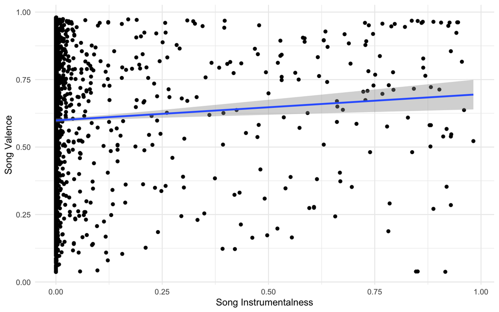

```r
ggplot(billboard, aes(instrumentalness, valence)) +
  geom_point() +
  theme_minimal() +
  geom_smooth(method = "lm") +
  labs(x = "Song Instrumentalness", y = "Song Valence")
```

The intrumentalness score have a strong cluster around 0.

## Correlation 4

### Exercise 7 -

Use the `cor.test()` function to run a different correlation. Select any two numeric variables of interest (different from exercise 1 & 3 & 5) for your correlation. Interpret the output in terms of significance and direction.

```r
cor.test(billboard$tempo, billboard$energy)
```

```
##
##  Pearson's product-moment correlation
##
## data:  billboard$tempo and billboard$energy
## t = 10.532, df = 4133, p-value < 2.2e-16
## alternative hypothesis: true correlation is not equal to 0
## 95 percent confidence interval:
##  0.1318425 0.1912131
## sample estimates:
##       cor
## 0.1616741
```

There is a small positive significant relationship between the tempo and energy of a song.

### Exercise 8 -

Create a ggplot scatterplot visualization of the two variables you selected for the previous correlation. Add a geom_smooth regression “lm” line to the plot. Interpret what you see. Make sure you clean up the labels and add a theme.

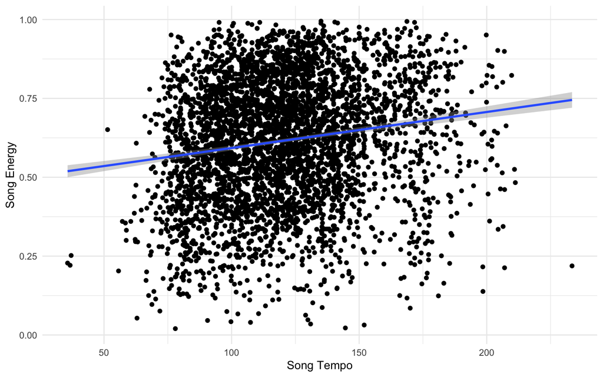

```r
ggplot(billboard, aes(tempo, energy)) +
  geom_point() +
  theme_minimal() +
  geom_smooth(method = "lm") +
  labs(x = "Song Tempo", y = "Song Energy")
```

While there is a big circular cluster in the middle, we do still see a slight positive trend happening between the two variables.